# aer13_OriginalHomeworkCode_05

Abby_Robinson

11/10/2021

#Boots for Days! ##Bootstrapping Standard Errors and CIs for Linear Models.

```r
library(curl)
```

load KamilarAndCooperData.csv dataset into R markdown file

```r
f <- curl("https://raw.githubusercontent.com/fuzzyatelin/fuzzyatelin.github.io/master/AN588_Fall21/KamilarAndCooperData.csv")
k <- read.csv(f, header = TRUE, sep = ",", stringsAsFactors = TRUE)
k
```

[output not shown]

[output cut: 2767 more lines]

[1] Using the “KamilarAndCooperData.csv” dataset, run a linear regression looking at log(HomeRange_km2) in relation to log(Body_mass_female_mean) and report your β coeffiecients (slope and intercept).

```r
model <- lm(log(HomeRange_km2) ~ log(Body_mass_female_mean), data = k)
model
```

```
##
## Call:
## lm(formula = log(HomeRange_km2) ~ log(Body_mass_female_mean),
##     data = k)
##
## Coefficients:
##                (Intercept)  log(Body_mass_female_mean)
##                     -9.441                       1.036
```

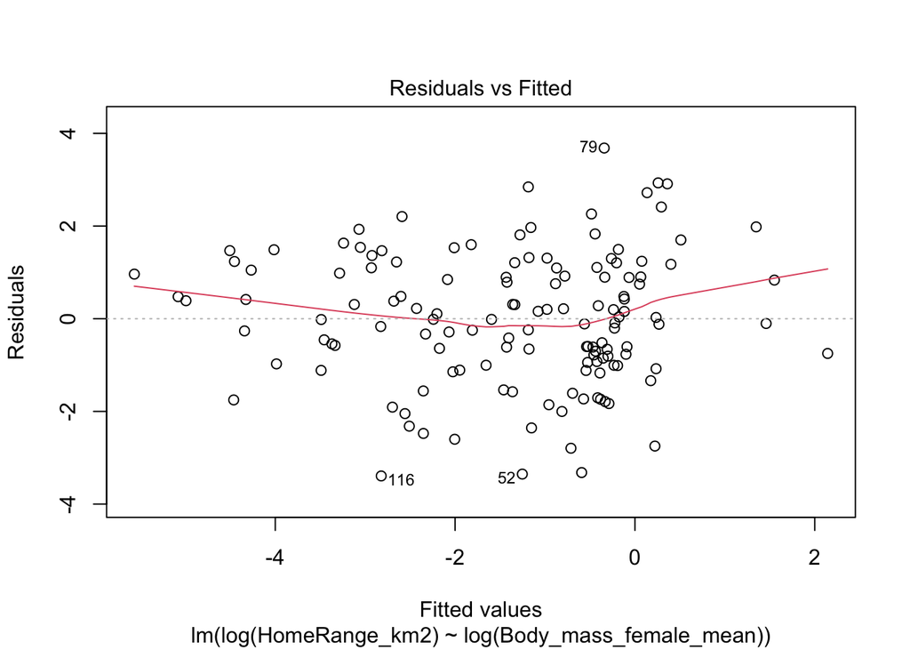

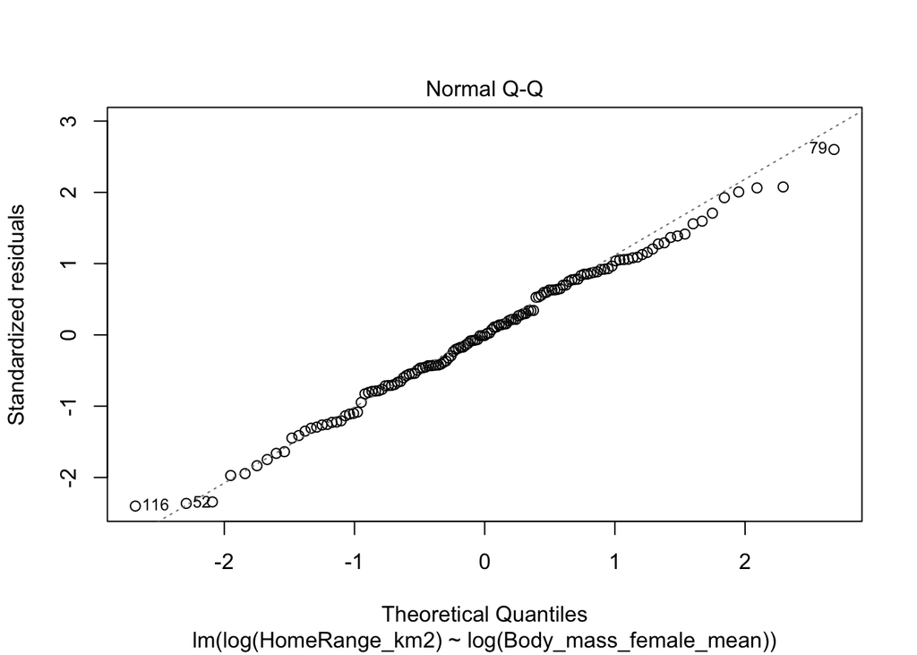

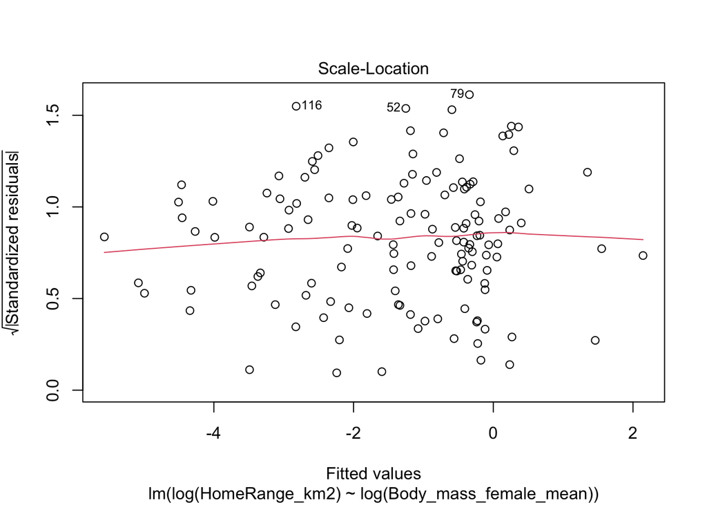

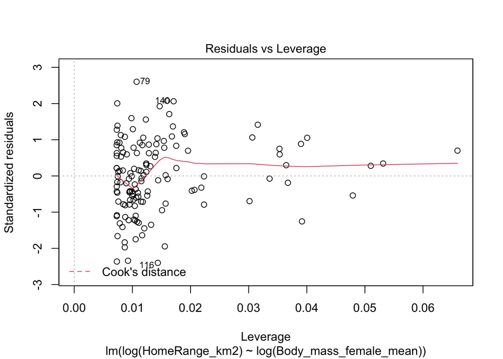

```r
##the intercept is -9.441 and the slope is 1.036

plot(model)  ##residuals look randomly distributed and the QQ plot is linear
```

#cece comments: looks good, I got almost the same slope and intercept, and my qq plot was linear too. I would just exclude the NAs here instead, use “na.action = na.exclude” after data=k. Its a lot easier than the code you did below [2] Then, use bootstrapping to sample from your data 1000 times with replacement, each time fitting the same model and calculating the same coefficients. This generates a sampling distribution for each β coefficient.

subset and rename home range and body mass data and remove NAs

```r
home <- k$HomeRange_km2
home
```

```
##   [1]     NA     NA     NA     NA  0.030  0.190  0.300  0.100  0.095     NA
##  [11]     NA     NA  0.105  0.020     NA     NA  2.280     NA  0.730  1.360
##  [21]  0.010  0.010  1.040  0.413  5.250     NA     NA     NA  0.070  0.047
##  [31]  0.290  0.320     NA  0.080     NA  0.100  0.020     NA  0.010  0.002
##  [41]  0.530  0.880  0.350  1.700     NA     NA  0.510     NA     NA     NA
##  [51]  0.160  0.010  0.240  1.250     NA     NA     NA  0.100     NA  0.060
##  [61]  1.150     NA  1.150     NA     NA     NA  0.020  0.020  2.250     NA
##  [71]     NA     NA  3.710  0.300  0.500  2.720  0.290  0.356 28.240  0.130
##  [81]     NA  0.700  0.123  0.162  0.053  0.042  0.200  0.584  0.070     NA
##  [91]     NA  0.040  0.080  0.010  0.010     NA  4.030  0.210  0.010     NA
## [101]  0.620  0.290  0.320  0.320  0.120  0.260  0.230  0.120  2.820  0.050
## [111]  0.240  0.830  0.260     NA  0.008  0.002     NA  0.003  0.008  1.980
## [121]  0.340     NA  0.007     NA     NA     NA  0.460  1.430     NA  5.910
## [131]  1.750     NA     NA  0.880  0.880  0.400  2.630     NA     NA 26.340
## [141]  0.010     NA  0.010  0.800  0.030  3.730  0.870     NA     NA     NA
## [151]     NA     NA  0.060  0.120 27.930 10.850  4.830 14.950 17.370  9.120
## [161]  0.110  0.020  0.420  0.326  0.390  0.113  0.650     NA  0.128     NA
## [171]  3.880  0.380  0.120  0.560     NA     NA  0.210  4.000  0.060  0.030
## [181]     NA 10.000 25.000 24.280     NA  0.200  0.160  0.220     NA  0.050
## [191]  0.210     NA  0.060     NA     NA  0.100  0.680  1.300  0.313  0.040
## [201]  0.004  0.048  1.160  0.030  0.120  2.220  0.080  0.330  0.958  0.430
## [211]  0.020     NA  1.390
```

```r
home <- na.omit(home)
mass <- k$Body_mass_female_mean
mass <- na.omit(mass)
mass
```

```
##   [1]  3180.0    84.0  5520.0  4240.0  4550.0  5350.0  6430.0  5210.0  1230.0
##  [10]   716.1   780.0  1040.0   933.3   698.0   306.0  8484.4  9160.0  7290.0
##  [19]  8070.0  1307.0   766.5  8070.0  6350.0  2880.0  2710.0   909.0  1030.0
##  [28]   956.0  1380.0  1210.0   468.0   360.0   380.0   322.0   311.7   122.0
##  [37]  2290.0  2489.1  2436.5  2633.3  2166.7  5660.0  5260.0  5500.0  6200.0
##  [46]  4261.9  2901.0  2700.0  2880.0  3900.0  2900.0  3360.0  3450.0  4628.0
##  [55]  2733.0  4130.0  4260.0  2918.2  2900.0  3920.0  2870.0   362.0   139.0
##  [64]  2960.0  3039.0  3575.8  3700.0  7570.0  7505.6  8300.0  7420.0  7220.0
##  [73]  2490.0  6500.0  2281.0  2130.0  1080.0  2333.3  2430.0  1281.5  1940.0
##  [82]  2270.0  1830.0   261.0   212.0   147.2   188.0    73.1   137.0 97500.0
##  [91] 71500.0   670.0  1251.0  1300.0  5820.0  5920.0  5380.9  6250.0  6010.3
## [100]  5440.0  6840.0  7020.0  2210.0   700.0   598.0   923.0   934.0   594.0
## [109]   803.0  6010.0  5760.0   269.0   193.0  8400.0  6900.0  4940.0  3517.9
## [118]  8030.0  4762.7  5670.5  6539.2  5470.0  2600.0  3855.7  6100.0  3200.0
## [127]  9625.0  9500.0 12500.0 12800.0    67.2    30.0    42.0  1560.0   312.0
## [136]  9729.6  7620.0  7320.0  1020.0   626.0   376.0  1110.0   734.0 33200.0
## [145] 40366.7 13300.0 12000.0 10300.0 14800.0   867.9   350.0  8210.0  5460.0
## [154]  7258.0  2070.0  1580.0 41148.0 36947.6  6710.0  6566.6  4200.0  3757.0
## [163]  3633.3  6210.0  5895.0  3590.0  2980.0  8440.0 11600.0   430.0   396.6
## [172]   534.4   475.0   539.0   591.0   538.0   370.0   445.1   750.0   680.0
## [181]   742.5 11340.0 10710.0   123.0   117.0 11700.0  6059.7  9500.0 11200.0
## [190]  6764.8  7182.0 11340.0  5103.0  3340.0  3520.0
## attr(,"na.action")
##  [1]  10  34  35  38  64  82  98 112 117 118 149 165 166 182 183 194 201 204
## attr(,"class")
## [1] "omit"
```

```r
pop.data <- as.data.frame(cbind(mass, home))
```

take a sample of 10 from the population

```r
sample.data <- pop.data[sample(nrow(pop.data), 10, replace = TRUE),]
sample.data
```

```
##       mass   home
## 72  7220.0  2.820
## 124 3855.7 25.000
## 80  1281.5  0.008
## 85   212.0  1.430
## 83  1830.0  0.007
## 178  445.1  0.160
## 27  1030.0  0.350
## 38  2489.1  0.020
## 110 6010.0  0.326
## 108  594.0  0.020
```

```r
sample.model <- lm(log(home) ~ log(mass), data = sample.data)
sample.model
```

```
##
## Call:
## lm(formula = log(home) ~ log(mass), data = sample.data)
##
## Coefficients:
## (Intercept)    log(mass)
##     -5.6355       0.5382
```

#cece comments: I think you may have done something wrong when you removed the NAs from the sample as your intercept and slope are off from what I have and what I’ve seen on others work.I’m not completely sure why you took a sample of 10 from the pop also.

```r
# Containers for the coefficients
sample_coef_intercept <- NULL
sample_coef_slope <- NULL

for (i in 1:1000) {
  #Creating a resampled dataset from the sample data
  sample_d = sample.data[sample(1:nrow(sample.data), nrow(sample.data), replace = TRUE), ]

  #Running the regression on these data
  model_bootstrap <- lm(home ~ mass, data = sample_d)

  #Saving the coefficients
  sample_coef_intercept <-
    c(sample_coef_intercept, model_bootstrap$coefficients[1])

  sample_coef_slope <-
    c(sample_coef_slope, model_bootstrap$coefficients[2])
}
###Source: https://towardsdatascience.com/bootstrap-regression-in-r-98bfe4ff5007
```

# I think your code itself works but I did it differently so I dont know for sure. But again your variables are off so the results when you run the “sampe_coef_intercept and slope” outputs are different.

call intercept coefficient sampling distribution

```r
sample_coef_intercept
```

[output not shown]

[output cut: 345 more lines]

```
##  0.8885957689 -0.8018112968  0.3162418500  0.8018036211  1.6299079414
##   (Intercept)   (Intercept)   (Intercept)   (Intercept)   (Intercept)
## -0.0041306412  0.1771878961  0.3490931900  0.6252516576 -0.2604599415
##   (Intercept)   (Intercept)   (Intercept)   (Intercept)   (Intercept)
## -0.2913343413  1.9518126455 -2.3038217297  2.9406774456 -2.9863133942
##   (Intercept)   (Intercept)   (Intercept)   (Intercept)   (Intercept)
##  0.3197604250  1.4292332877  3.0680090642  0.6327793463 -0.4235719940
##   (Intercept)   (Intercept)   (Intercept)   (Intercept)   (Intercept)
## -0.3086481026 -0.0607896904 -0.0169228581  0.9104350325  0.5764378392
##   (Intercept)   (Intercept)   (Intercept)   (Intercept)   (Intercept)
##  5.6788764096  0.1125373463  4.2753932228 -0.9030257668 -5.6531237395
##   (Intercept)   (Intercept)   (Intercept)   (Intercept)   (Intercept)
##  1.6290835404  1.5965168861  0.4982012448  6.1508654570  1.1948428486
##   (Intercept)   (Intercept)   (Intercept)   (Intercept)   (Intercept)
##  0.4399480145  0.3341110342  0.9524322025 -0.3811577079 -0.3628404861
```

call slope coefficient sampling distribution

```r
sample_coef_slope
```

[output not shown]

[output cut: 345 more lines]

```
##  7.756828e-04  2.597772e-03  2.669921e-03  8.457846e-04  5.691340e-04
##          mass          mass          mass          mass          mass
##  5.295397e-05  2.937840e-04  1.697529e-04  8.952697e-04  2.594275e-04
##          mass          mass          mass          mass          mass
##  3.281298e-04  2.439449e-03  4.763154e-03  2.830347e-03  4.487642e-03
##          mass          mass          mass          mass          mass
## -2.389518e-05  7.380218e-04  1.129666e-04  9.209640e-04  3.834899e-04
##          mass          mass          mass          mass          mass
##  3.440056e-04  1.359379e-03  2.140867e-04  8.319955e-04  8.731610e-04
##          mass          mass          mass          mass          mass
##  1.353199e-03  8.722945e-04  1.336337e-03  2.712406e-03  6.636033e-03
##          mass          mass          mass          mass          mass
##  5.488996e-04  5.101182e-04  2.601291e-03  4.531892e-04  6.298781e-04
##          mass          mass          mass          mass          mass
##  2.802352e-04  2.433585e-04  8.257439e-04  1.446750e-03  2.433495e-03
```

# Cece: I believe to call slope and intercept for these variables you need to use i.set[i] <- a[1,] for intercept and s.set[i] <- a[2,] for slope. You can’t just call the variable itself.

Estimate the standard error for each of your β coefficients as the standard deviation of the sampling distribution from your bootstrap and determine the 95% CI for each of your β coefficients based on the appropriate quantiles from your sampling distribution.

standard deviation

```r
sd(sample_coef_intercept) #standard deviation for the intercept coefficient
```

```
## [1] 2.242475
```

```r
sd(sample_coef_slope) #standard deviation for the slope coefficient
```

```
## [1] 0.001662437
```

95% CI

```r
quantile(sample_coef_intercept, c(0.025, 0.975))
```

```
##      2.5%     97.5%
## -5.994755  4.725827
```

```r
##Got this from module 7, not sure if its right...
```

#cece: I believe you need CIs for both B0 and B1

##How does the former compare to the SE estimated from your entire dataset using the formula for standard error implemented in lm()?

```r
summary(model)
```

```
##
## Call:
## lm(formula = log(HomeRange_km2) ~ log(Body_mass_female_mean),
##     data = k)
##
## Residuals:
##     Min      1Q  Median      3Q     Max
## -3.3929 -0.9433 -0.0126  1.0944  3.6826
##
## Coefficients:
##                            Estimate Std. Error t value Pr(>|t|)
## (Intercept)                -9.44123    0.67293  -14.03   <2e-16 ***
## log(Body_mass_female_mean)  1.03643    0.08488   12.21   <2e-16 ***
## ---
## Signif. codes:  0 '***' 0.001 '**' 0.01 '*' 0.05 '.' 0.1 ' ' 1
##
## Residual standard error: 1.423 on 135 degrees of freedom
##   (76 observations deleted due to missingness)
## Multiple R-squared:  0.5248, Adjusted R-squared:  0.5213
## F-statistic: 149.1 on 1 and 135 DF,  p-value: < 2.2e-16
```

##How does the latter compare to the 95% CI estimated from your entire dataset?

#Cece: Make sure you call the CI for the original model so you can compare it, I don’t see code for this. Use confint(model,.95)

##Challenges:

1. I got an error when I tried to sample from the whole population because there were too many NAs in the dataset and the sample was only pulling NAs values, but I removed the NAs and that fixed the problem
2. I originally had the “sample.data” code inside the bootstrap loop, but this was just giving the same number 1000 times when I ran the bootstrap, so I put that code outside of the actual bootstrap loop and that seemed to fix the problem!